Leandro Lopez  
Merrimack College, CS6023

# Linear Programming

```python
import numpy as np
import matplotlib.pyplot as plt
import pandas as pd
from IPython.display import display
```

To Maximize profits, we should balance the number of sandwiches and pizzas so that we have **6 pizzas** and **4 sandwiches**

Pizza(x) = sell for $50, cost $25 = $25 Sandwiches(y) = sell for $20, cost $5 = $15

P(x,y) = 25x + 15y

Time Constraint: 8x + 3y = <= 60  
Quantity Constraint: x + y = 10

## Time Constraint:

8x + 3y = 60  
3y = 60 - 8x  
y = (60 - 8x)/3  
y = 20 - (8/3)x

## Quantity Constraint:

x + y = 10  
y = 10 - x

## Intersection:

8x + 3(10 - x) = 60  
8x + 30 - 3x = 60  
5x = 30  
x = 6

y = 10 - 6 = 4

## Pizzas only

Time constraint: x = 60/8 = 7.5, round to 7  
y = 0  
x = 10  
P(7,0) = 25(7) + 15(0) = 175

## Sandwiches only

Time constraint: x = 60/3 = 20, but we can only make 10 y = 10 x = 0 P(0,10) = 25(0) + 12 (10) = 150

## Balanced option

Quantity constraint: x + y = 10  
y = 10 - x  
plug into time constraint  
8x + 3(10 - x) = 60  
8x + 30 - 3x = 60  
5x + 30 = 60  
5x = 30  
x = 6  
y = 10 - 6  
y = 4  
x = 6, y = 4  
P(6,4) = 25(6) + 15(4) = 150 + 60 = 210

## Conclusion

Given the time constraints and quantity constraints, a balanced approach is the best approach.  
If we could only do pizzas, without time constraints, we could do 10 pizzas at $25 = $250.  
If we could only do sandwiches, without the quantity constraints, we could do 20 sandwiches at $15 = $300.  
Because of our constraints, the best option is the Balanced Option, 6 pizzas and 4 sandwiches, at $210.

```python
# Define the data
data = {
    'Parameter': ['Profit from pizza', 'Profit from sandwich', 'Time for pizza', 'Time for sandwich', 'Total time', 'Quantity'],
    'Value/Expression': ['$25', '$15', '8 minutes', '3 minutes', '60 minutes', '10 items']
}

# Create a DataFrame
df = pd.DataFrame(data)

# Display the DataFrame as a table
display(df)
```

|  | Parameter | Value/Expression |
| --- | --- | --- |
| 0 | Profit from pizza | $25 |
| 1 | Profit from sandwich | $15 |
| 2 | Time for pizza | 8 minutes |
| 3 | Time for sandwich | 3 minutes |
| 4 | Total time | 60 minutes |
| 5 | Quantity | 10 items |

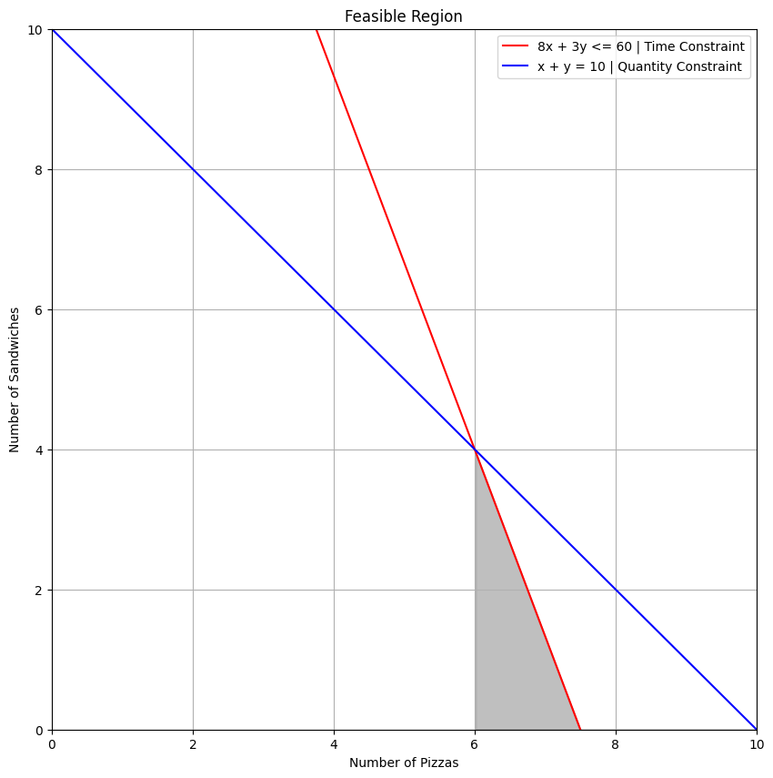

```python
# Generate x values
x = np.linspace(0, 10, 400)

y1 = (60 - 8*x)/3 # Time constraint, 8x + 3y = 60 -> (60 - 8x) / 3
y2 = 10 - x # Quantity constraint, x + y = 10 -> y = 10 - x

plt.figure(figsize=(10,10))

# Plotting constraints
plt.plot(x, y1, '-r', label="8x + 3y <= 60 | Time Constraint")
plt.plot(x, y2, '-b', label="x + y = 10 | Quantity Constraint")
plt.fill_between(x, 0, y1, where = ((y1<=y2) & (x<=10)), color = 'gray', alpha = 0.5)

# Setting the labels and title
plt.title("Feasible Region")
plt.xlabel("Number of Pizzas")
plt.ylabel("Number of Sandwiches")
plt.xlim((0, 10))
plt.ylim((0, 10))

# Adding the legend
plt.legend()

# Adding grid
plt.grid(True)

# Showing the plot
plt.show()
```